# A Simple Technique for Self-Calibration

Alexander Kruglyak

Sofya Zybtsovsky

### Introduction

The goal of Computer Vision is to compute properties (mainly geometric) of the three-dimensional world from images. One of the challenging problems of Computer Vision is to reconstruct a 3D model of a scene from a moving camera.  
Possible applications include: navigation of autonomous vehicles, objects recognition, reverse engineering and synthesis of virtual environments.

In general, assumption that the intrinsic parameters of the camera (focal length, image center and aspect ratio) are known.  
Computing camera motion in this case is a well known problem in photogrammetry, called relative orientation, for which several methods are available.  
Given all the parameters of the camera, reconstruction is straightforward.

### Projection

We want a mathematical model to describe how 3D World points get projected into 2D Pixel coordinates.

### Forward projection

[figure not shown]

### Backward projection

[figure not shown]

## Mathematical model

[figure not shown]

## Self-calibration

Self-calibration is the process of finding intrinsic parameters of the camera without any actual calibration object:

- focal length
- image center (principal point)
- aspect ratio (pixel skew)

### Intrinsic matrix K

5 degrees of freedom: 2 for focal length, 2 for offset, and 1 for skewness

[figure not shown]

## Approaches to find calibration matrix

### Hartley algorithm

- non-iterative algorithm
- finds only focal lengths
- requires at least 8 conjugate pairs points
- “heavy” mathematics calculation (SVD, determinants equation, and many equation, and more...)

### Hartley algorithm - disadvantages

- determining only the focal lengths
- requires all other internal camera parameters to be known
- heavy computations

### Mendonca - algorithm

- extension of Hartley’s self-calibration technique
- Input: at least 24 points (3+ images such as each contains 8+ correspondence points)
- Output: **all** intrinsic parameters

### Mendonca - algorithm

Based on the theorem of essential matrix E=[t]<sub>x</sub>R:

A real matrix E<sub>3x3</sub> can be factorized as product of a nonzero skew-symmetric matrix **t** (translation) and a rotation matrix **R**  
**if and only if**  
E has 2 identical singular values and a zero singular value  
E<sub>3x3</sub> =[t]<sub>x</sub>R <=> <sup>1</sup>𝞼=<sup>2</sup>𝞼, <sup>3</sup>𝞼=0

### Mendonca - algorithm

algo aims to find 2 singular values (other than zero) that are as close as possible:  
<sup>1</sup>𝞼 - <sup>2</sup>𝞼 -> 0  
K found by algo -> true intrinsic matrix

### Mendonca algorithm

Input: at least 24 points (3+ images such as each contains 8+ correspondence points)

Output: K (intrinsic parameters)

1. Init some random matrix K
2. Calculate fundamental matrix **F** for each pair of images
3. Calculate essential matrix **E** for each pair of images (based on F and K)
4. Decompose E and find singular values (SVD)
5. Calculate error (cost function)
6. Minimize error
7. Then cost function reach global minimum: return K

### Input

50 points with 5 different views

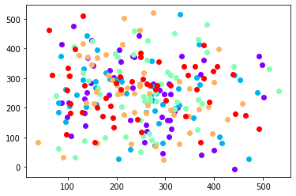

```python
plot_2d(imagePoints)
```

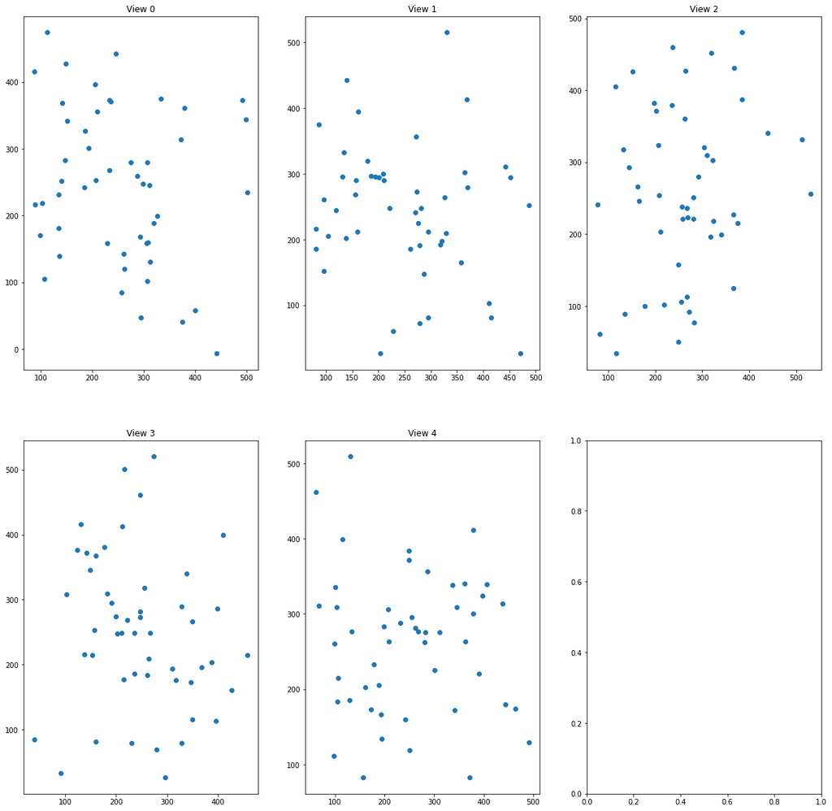

```python
plot_2d_separate(imagePoints)
```

```python
print(imagePoints.shape)
print(imagePoints)
```

[output not shown]

[output cut: 95 more lines]

[output not shown]

### 1. Init some random matrix K

```python
initial_K = [100,0,100,200]
print(np.array([[initial_K[0],0,initial_K[1]],[0,initial_K[2],initial_K[3]],[0,0,1]]))
```

```
[[100   0   0]
 [  0 100 200]
 [  0   0   1]]
```

### 2. Calculate fundamental matrix F for each pair of images (for example via 8-point algorithm with data normalization)

```python
def calc_fund_matrix(points1,points2):
    '''
    Takes in 2 arrays of matching points
    Return Fundamental matrix
    '''
    F, mask = cv2.findFundamentalMat(points1,points2)

    return F

Fs = np.zeros((3,3,numberOfViews,numberOfViews))

for i in range(numberOfViews):
    for j in range(i+1,numberOfViews):
        Fs[:,:,i,j] = calc_fund_matrix(imagePoints[:,:,i],imagePoints[:,:,j])
```

### 3. Calculate essential matrix E for each pair of images (based on F and K)

```python
def calculate_essential_matrix(K,F):
    return K.T @ F @ K
```

### 4. Decompose E and find singular values (SVD)

```python
def decompose_singular_values(E):
    _,D,_ = np.linalg.svd(E)
    # Singular Values (3rd value, D[3] is 0 according to theorem)
    r = D[0]
    s = D[1]
    return r, s
```

### 5. Calculate error (cost function)

<sup>1</sup>𝞼<sub>ij</sub> , <sup>2</sup>𝞼<sub>ij</sub> - non zero singular values of E<sub>ij</sub> = K<sup>T</sup><sub>i</sub>F<sub>ij</sub>K<sub>j</sub>, such as <sup>1</sup>𝞼<sub>ij</sub> > <sup>2</sup>𝞼<sub>ij</sub>

w<sub>ij</sub> - normalized weight factors

Minimize cost function:

[figure not shown]

```python
def mendonca_cost_func(X):
    '''
    computes Mendonca & Cipolla Cost function to find the Optimal Intrinsic Parameters
    Input
    X      - Approximate Values of Intrinsics - 1D array with length 5
    Output
    cost    - Computed Cost
    '''

    K = np.array([
        [X[0],0,X[1]],
        [0,X[2],X[3]],
        [0,0,1]
    ])
    cost = 0
    nof_images = numberOfViews
    Den = nof_images*(nof_images-1)/2

    for i in range(0,nof_images-1):
        for j in range (i+1,nof_images):
            E = calculate_essential_matrix(K, Fs[:,:,i,j])
            r,s = decompose_singular_values(E)
            cost+= (1/Den) * (r - s)/s

    return cost
```

### 6. Minimize error (e.g, via least squares)

```python
res = opt.minimize(mendonca_cost_func,x0=initial_K, method='Nelder-Mead')
```

### 7. Then cost function reach global minimum: return K

```python
result_K = np.array([
    [ res.x[0], 0 ,       res.x[1] ],
    [ 0,        res.x[2], res.x[3] ],
    [ 0,        0,        1        ]
])
print ("Result K\n",np.matrix(result_K))
print("True K\n",true_K)
```

```
Result K
 [[799.98946037   0.         255.99919228]
 [  0.         799.98861106 255.99955088]
 [  0.           0.           1.        ]]
True K
 [[800   0 256]
 [  0 800 256]
 [  0   0   1]]
```

### Mendonca | Advantages

- simple mathematical calculation
- find all unknown intrinsic camera parameters
- always converges to the global minimum
- has no bias towards any particular image of the sequence
- insensitive to the initialization

Mendonca, Paulo RS & Roberto Cipolla "A simple technique for self-calibration" 1999, University of Cambridge, UK